# Neat and Tidy: Mapping COVID-19 Data with Tidyverse

Animating choropleths with ‘urbnmapr’ and ‘gganimate’

Alexander Carlton

2020-04-13

This page is part of a [Neat and Tidy](https://www.fisodd.com/code/neat-and-tidy) project with multiple articles on different ways to use the [Tidyverse](https://www.tidyverse.org/) to manage real world data.

COVID-19 has triggered many questions. One of the most basic questions with any viral outbreak is “Where?”

The good folks at the Johns Hopkins University CSSE provide one of the commonly sited views of the current COVID-19 situation, https://coronavirus.jhu.edu/map.html

But since these folks also have released their data via GitHub, https://github.com/CSSEGISandData/COVID-19, everyone can create customized views into this information and produce maps to suit their specific interests.

# Set Up

## Environment

A good tool improves the way you work. A great tool improves the way you think. – Jeff Duntemann

```r
library(tidyverse)
library(gganimate)
library(urbnmapr)
library(scales)
library(gifski)
```

## Configuration

A few parameters for controling or adapting this script to suit the local needs.

```r
# This file will be created at the end
output_filename <- "animation.gif"

# The following are based on the local copy of the data
jhu_directory <- "COVID-19/csse_covid_19_data/csse_covid_19_time_series/"
jhu_cases_filename <- "time_series_covid19_confirmed_US.csv"
jhu_death_filename <- "time_series_covid19_deaths_US.csv"

# Minimum population to include in map (tiny populations can have difficult variance)
min_pop <- 10000
```

Amongst the many files provided in this repository, our immediate focus are the time_series files, specifically the ones for the US: the one tracking Confirmed Cases and the one tracking Deaths.

The [COVID-19 repository](https://github.com/CSSEGISandData/COVID-19) is a great resource for sane, fresh data on a very difficult problem. Their Center for Systems Science and Engineering (JHU CSSE) has become famous for [their dashboard](https://coronavirus.jhu.edu/map.html), but making the raw data available on [their GitHub](https://github.com/CSSEGISandData/COVID-19) has enabled so many others to learn. We are very grateful.

```r
# Fetch JHU data
jhu_cols <- cols(
    .default = col_double(),
    UID = col_character(),
    iso2 = col_character(),
    iso3 = col_character(),
    FIPS = col_character(),
    Admin2 = col_character(),
    Province_State = col_character(),
    Country_Region = col_character(),
    Combined_Key = col_character()
)

# Fetch the Cases and then the Death data
jhu_cases_data <- read_csv(
    paste0(jhu_directory, jhu_cases_filename),
    col_types = jhu_cols
) %>%
    select(
        -UID, -iso2, -iso3, -code3, -Lat, -Long_, -Country_Region
    ) %>%
    rename(
        County = "Admin2",
        State = "Province_State"
    )
jhu_death_data <- read_csv(
    paste0(jhu_directory, jhu_death_filename),
    col_types = jhu_cols
) %>%
    select(
        -UID, -iso2, -iso3, -code3, -Lat, -Long_, -Country_Region
    ) %>%
    rename(
        County = "Admin2",
        State = "Province_State"
    )
```

The data in these time_series files has new columns added each day. For our use here we need to transform these spreadsheets into tidy data.

While we are at it, we process the “FIPS” values (which are a set of standardized labels for each county in the US) into a form that makes life much easier later, when we join with our mapping points.

```r
# Turn the JHU data into a 'tidy' form (with a proper Date field)
tidy_cases_data <- jhu_cases_data %>%
    pivot_longer(
        -c(County, State, Combined_Key, FIPS),
        names_to = "date_str",
        values_to = "Cases"
    ) %>%
    mutate(
        Date = as.Date(date_str, "%m/%d/%y"),
        date_str = NULL,
        county_fips = sprintf("%05d", as.integer(FIPS)),
        FIPS = NULL
    )
tidy_death_data <- jhu_death_data %>%
    pivot_longer(
        -c(County, State, Combined_Key, Population, FIPS),
        names_to = "date_str",
        values_to = "Death"
    ) %>%
    mutate(
        Date = as.Date(date_str, "%m/%d/%y"),
        date_str = NULL,
        county_fips = sprintf("%05d", as.integer(FIPS)),
        FIPS = NULL
    )
```

Then once we have the data in tidy form, it is easy to manipulate it into what we need.

Joining the Cases and the Deaths together allows an analysis of morbidity, but in this case it also happens to bring in a column of Population data from the Deaths file that is very useful for the Cases data.

```r
# Joining also gives us a Population field to use
tidy_data <- tidy_cases_data %>%
    left_join(
        tidy_death_data,
        by = c("County", "State", "Combined_Key", "county_fips", "Date")
    )
```

# Operate

Since we are focused on mapmaking, we can remove the entries that don’t fit into our maps.

Yes, there’s a degree of inaccuracy created by just dropping the data out, but at the scales being used here the “unassigned” and out-of-state cases are not significant enough to change the picture. *Note:* this assumption is not safe, and needs to be tested before one does any serious analysis.

```r
dataset <- tidy_data %>%
    filter(
        !County == "Unassigned",
        !str_detect(County, "Out of "),
        Population > min_pop # Drops the cruise ships and tiny principalities
    ) %>%
    mutate(
        value = if_else(
            Cases != 0,
            Cases / (Population / 1000000),
            NA_real_  # For display purposes, convert '0' to 'na' (white out)
        )
    )
```

Having made the (gross) simplification of dropping out the problematic elements, we can now focus on making maps.

First step is to generate a minimal dataset, stripping out anything not used in these maps.

The size of the tibbles multiplies quickly when we join with all the map points, so the more we can eliminate now the less stuff the plot needs to grind through when making each image. Something that can be appreciated when we need to grind through a hundred images to make an animation.

```r
# Note: these could be customized...
start_date <- min(dataset$Date)
end_date <- max(dataset$Date)

# join desired data with map points and then drop the unneeded cols
mapset <- dataset %>%
    filter(
        Date >= start_date,
        Date <= end_date
    ) %>%
    mutate(
        region = tolower(State),
        subregion = tolower(County)
    ) %>%
    select(
        -Combined_Key,
        -County, -State,
        -Cases, -Death, -Population
    )
```

The last operation is to join in the map points.

Again, we are working the potentially sharp edges of the boundaries between accuracy and usefulness.

For this exercise the county-level information as provided by `urbnmapr` (the very handy US map assistant from the Urban Institute team) provides just what we need [border points to draw at both the county and at the state level precalculated with a transform that pulls Alaska and Hawaii across the Pacific to nestle in where the real world has Baja California – not necessarily accurate, but effective and very recognizable for a US audience].

```r
mapinfo <- mapset %>%
    right_join(urbnmapr::counties, by = "county_fips")
```

# Display

Lots of functions with lots of arguments, but mostly this is just for style.

The one tricky item here is the coloring of the counties. This chart uses `scale_fill_viridis_c` for coloring, but here we specify a “log10” transformation (linear distance along this color line represents changes of orders of magnitude in cases per million in population) so that the few locations with very high rates don’t force everywhere else into a dull monotone.

As was touched on when dropping the “unassigned” values above, this is another area where one needs to be careful. The `log10` function is an exaggeration, and while exaggeration is a powerful tool to pull attention to the selected area of interest, there comes a point where it is difficult (if not impossible) to differentiate between an overdone exaggeration and a simple lie.

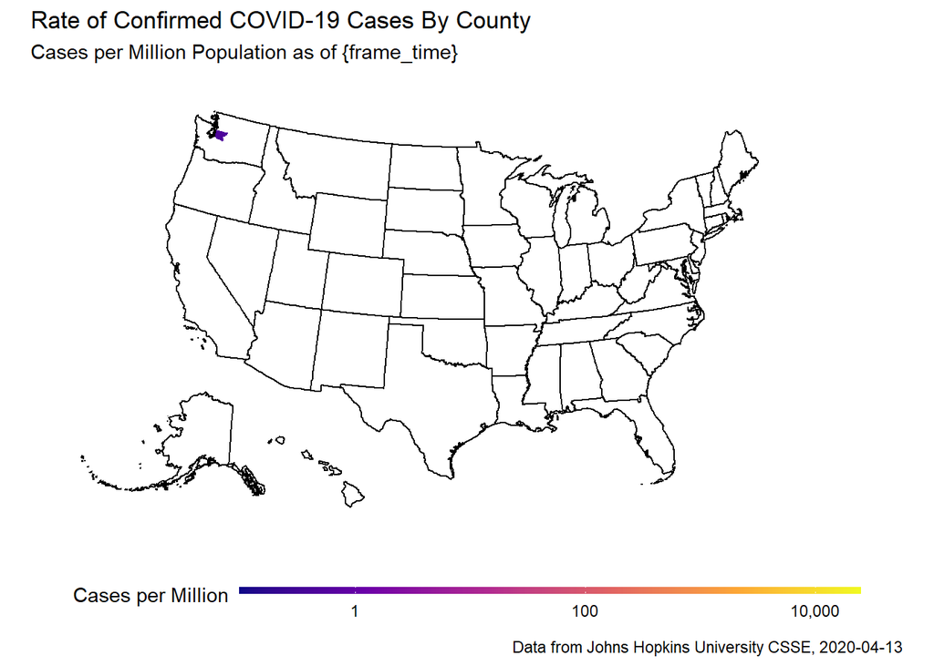

```r
# Use the last date with values as a proxy for a timestamp for the dataset
last_date <- max(tidy_data$Date)

# Build the plot
g <- ggplot() +
    # County-level data
    geom_polygon(
        data = mapinfo,
        mapping = aes(x = long, y = lat, group = group, fill = value),
        color = NA
    ) +
    # Colored brightly
    scale_fill_viridis_c(
        name = "Cases per Million",
        trans = "log10", # bring out differences of less afflected counties
        n.breaks = 5,
        labels = label_comma(),
        na.value = "white",
        option = "C"
    ) +
    # State outlines
    geom_polygon(
        data = urbnmapr::states,
        mapping = aes(long, lat, group = group),
        fill = NA,
        color = "black",
        size = 0.4
    ) +
    # projected in a reasonable manner for a decent map
    coord_map("albers", lat0 = 45.5, lat1 = 29.5) +
    scale_x_continuous(breaks = NULL) +
    scale_y_continuous(breaks = NULL) +
    # Hack the legend to be wide across the bottom of the chart
    guides(
        fill = guide_colorbar(
            barwidth = unit(0.666, "npc"),
            barheight = unit(0.01, "npc")
        )
    ) +
    # Labels (with "frame_time" to be supplied by gganimate below)
    labs(
        title = "Rate of Confirmed COVID-19 Cases By County",
        subtitle = "Cases per Million Population as of {frame_time}",
        caption = paste("Data from Johns Hopkins University CSSE,", last_date),
        x = NULL,
        y = NULL
    ) +
    # Clean theme, but do push the legend/guide to be displayed below chart
    theme_minimal() +
    theme(
        legend.title = element_text(vjust = 1),
        legend.position = "bottom"
    )
print(g)
```

And we have our base chart.

Yes, it looks very bare with only one reported case in Washington. But that’s only how things started, the map will look very different as we move forward in time.

# Animate

Now that we have the base chart, with the `gganimate` library animation has been made very easy. Effectively all we need to do is to declare what is the variable we are using to step through the dataset, and then just specify a few basic parameters in the call to animate – here the parameters are basically the default with the one exception of specifying that we will end the animation loop by displaying the (unchanging) final image for the last three seconds before repeating.

The one trick here is that we’ve chosen to use “{frame_time}” in the subtitle for the chart so that during animation this will be replaced by the current date as is generated by the `transition_time()` function.

```r
# Note: this can take a while to execute
# -- many days of data
# -- lots and lots of (border) points in every image

# Animate by Date
anim <- g +
    transition_time(Date, range = c(start_date, end_date))
loop <- animate(
    anim,
    nframes = 100, fps = 10, # 10 second clip
    end_pause = 30 # hold still for last 30 frames (3 secs)
)
anim_save(output_filename)
```

All of which produces this animation.

“How did you go bankrupt?” Bill asked. “Two ways,” Mike said. “Gradually and then suddenly.” – Ernest Hemmingway, *The Sun Also Rises*

```r
loop
```

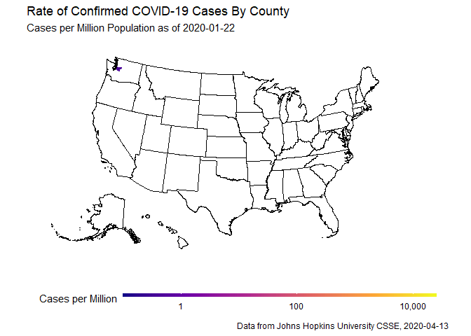